# Taller 1. Minería de datos. Scrapping Journal of Statistical Software(JSS)

# Construcción de la base SQLite

A pesar de que la estrcutura de la que se ha dotado a los datos deberíoa prestarse para la definición de una base de datos relacionales. Se presumieron cosas desde un inicio que realmente no eran ciertas:

- Todos los autores no tienen ORCID por ende no debería usarse como ID
- Hay errores en la relación de [ORCID y autor](https://www.jstatsoft.org/article/view/v101i02), en ocasiones varios autores en el mismo autor tienden a tener el mismo ORCID

Por estas razones, solamente se crean tablas sin relaciones entre ellas y se poblan con la información que se obtuvo mediante el scrapping. No se tiene en cuenta el año 2019 en algunas de las preguntas principalmente porque los autores no tenían ORCID en las versiones iniciales de los artículos.

```r
library(DBI)
library(RSQLite)
library(dplyr)

setwd(getSrcDirectory(function() {}))

cat('

------------ JSS Database Construction ------------
This process requires the following tables to be
available in the environment:

  * vol
  * articles
  * authors
  * authorship
  * references

Upon completion, a jss.sqlite file will be created
in the current working directory\n')

cat('* STATUS: Building ...\r')

con <- dbConnect(RSQLite::SQLite(), "JSS.sqlite")

# ------------------------------------- CREACIÓN DE TABLAS -----------------------------------------
# Se eliminan las tablas si ya existen para garantizar una inserción limpia en cada ejecución

dbExecute(con, "DROP TABLE IF EXISTS vol")
dbExecute(con, "
  CREATE TABLE vol (
    id     INTEGER,
    ord    INTEGER,
    year   INTEGER,
    url    TEXT
  )
")

# 'order' es una palabra reservada en SQL, por eso se renombra a 'ord'

dbExecute(con, "DROP TABLE IF EXISTS articles")
dbExecute(con, "
  CREATE TABLE articles (
    DOI                   TEXT,
    vol_id                INTEGER,
    title                 TEXT,
    issue                 INTEGER,
    url                   TEXT,
    abstract              TEXT,
    date                  TEXT,
    n_citations           INTEGER,
    n_references          INTEGER,
    influential_citations INTEGER,
    topic                 TEXT
  )
")

dbExecute(con, "DROP TABLE IF EXISTS authors")
dbExecute(con, "
  CREATE TABLE authors (
    ORCID  TEXT,
    author TEXT
  )
")

dbExecute(con, "DROP TABLE IF EXISTS authorship")
dbExecute(con, "
  CREATE TABLE authorship (
    ORCID TEXT,
    DOI   TEXT
  )
")

dbExecute(con, "DROP TABLE IF EXISTS ref")
dbExecute(con, "
  CREATE TABLE ref (
    DOI_origin    TEXT,
    DOI_reference TEXT,
    paperId       TEXT
  )
")

# --------------------------------- PREPARACIÓN DE LOS DATOS ---------------------------------------
# Antes de insertar se hacen los ajustes necesarios para que los datos sean coherentes
# con los nombres de columna definidos en cada tabla

vol_db <- vol |>
  rename(ord = order)

articles_db <- articles |>
  rename(
    vol_id                = vol.id,
    influential_citations = `influential citations`,
    n_references          = references,
    n_citations           = citations
  ) |>
  select(DOI, vol_id, title, issue, url, abstract, date,
         n_citations, n_references, influential_citations, topic)

authors_db <- authors |>
  filter(ORCID != "")

authorship_db <- authorship

references_db <- references |>
  rename(
    DOI_origin    = DOI.origin,
    DOI_reference = DOI.reference
  )

# --------------------------------------- INSERCIÓN ------------------------------------------------

dbAppendTable(con, "vol",        vol_db)
dbAppendTable(con, "articles",   articles_db)
dbAppendTable(con, "authors",    authors_db)
dbAppendTable(con, "authorship", authorship_db)
dbAppendTable(con, "ref",        references_db)

dbDisconnect(con)

cat('* STATUS: DONE         \n')
```

Si bien la información de los autores podría completarse con otras fuentes (como Semantic Scholar) por el momento simplemente continuaremos con la información de la página del journal.

```r
library(DBI)
library(RSQLite)
con <- dbConnect(RSQLite::SQLite(), "JSS.sqlite")
```

# Consultas SQL

> **¿Cuál es el número promedio de autores por paper?**

> Debido a como se organizo la tabla de autores y autoría, simplemente con agrupar por DOI en la tabla authorship y contar la cantidad de elementos. Además de hacer left joins para identificar de qué año son los conteos.

> **En 2025 se tienen alrededor de 2.9 autores por artículo**

### Consulta

```r
avg_authors <- dbGetQuery(con, "
  SELECT
      v.year,
      AVG(n_authors) AS avg_authors_per_paper
  FROM (
      SELECT
          a.DOI,
          a.vol_id,
          COUNT(au.ORCID) AS n_authors
      FROM      articles   a
      LEFT JOIN authorship au ON a.DOI = au.DOI
      GROUP BY  a.DOI, a.vol_id
  ) sub
  LEFT JOIN vol v ON sub.vol_id = v.id
  WHERE v.year != 2019
  GROUP BY v.year
  ORDER BY v.year
")
```

### Tabla

| Año | Autores promedio |
| --- | --- |
| 2020 | 0.0945946 |
| 2021 | 1.3076923 |
| 2022 | 2.4363636 |
| 2023 | 3.0937500 |
| 2024 | 2.9230769 |
| 2025 | 2.9534884 |

### Gráfico

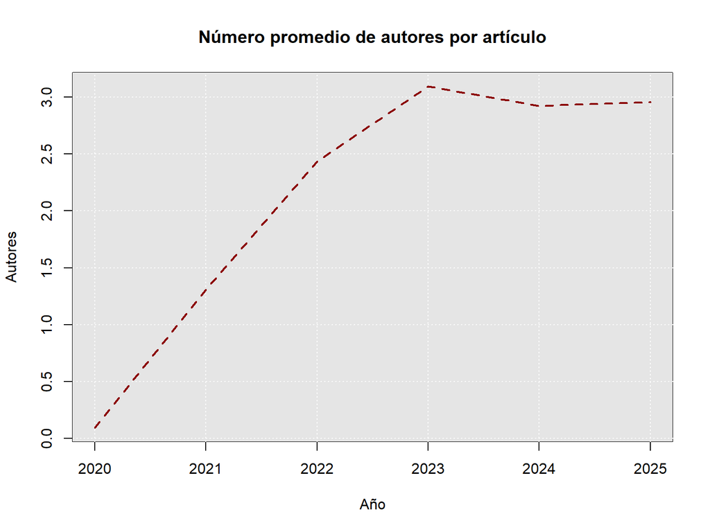

> **¿Cuántos artículos están relacionados con Machine Learning?**

> **De los 43 artículos escritos en 2025 solamente 3 presentaron aportes nuevos al campo del machine learning.**

### Consulta

```r
ml_count <- dbGetQuery(con, "
  SELECT
      v.year,
      COUNT(*) AS n_articles
  FROM      articles a
  LEFT JOIN vol      v ON a.vol_id = v.id
  WHERE a.topic = 'Machine Learning'
  GROUP BY v.year
  ORDER BY v.year
")
ml_count
```

```
##   year n_articles
## 1 2019          1
## 2 2020          2
## 3 2021          5
## 4 2022          4
## 5 2023          1
## 6 2024          5
## 7 2025          3
```

### Tabla

| Año | Artículos ML |
| --- | --- |
| 2019 | 1 |
| 2020 | 2 |
| 2021 | 5 |
| 2022 | 4 |
| 2023 | 1 |
| 2024 | 5 |
| 2025 | 3 |

### Gráfico

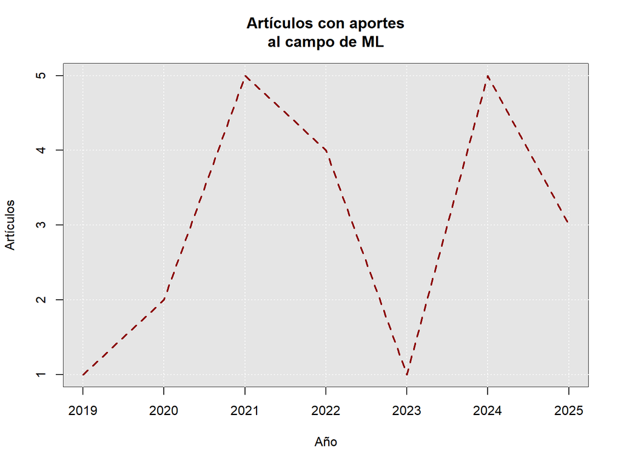

> **¿Cuántos artículos están relacionados con IA generativa?**

> **De los 43 artículos escritos en 2025 ningunó presentó aportes nuevos al campo de la IA generativa**

### Consulta

```r
gen_count <- dbGetQuery(con, "
  SELECT
      v.year,
      COUNT(*) AS n_articles
  FROM      articles a
  LEFT JOIN vol      v ON a.vol_id = v.id
  WHERE a.topic = 'Generative AI'
  GROUP BY v.year
  ORDER BY v.year
")
```

### Tabla

| Año | Artículos de IA generativa |
| --- | --- |
| 2020 | 1 |
| 2021 | 1 |

> **¿Cuántos artículos están relacionados con otros temas estadísticos?**

> **De los 43 artículos escritos en 2025, 18 presentaron aportes nuevos a otros campos de la estadística.**

### Consulta

```r
sta_count <- dbGetQuery(con, "
  SELECT
      v.year,
      COUNT(*) AS n_articles
  FROM      articles a
  LEFT JOIN vol      v ON a.vol_id = v.id
  WHERE a.topic = 'Statistics'
  GROUP BY v.year
  ORDER BY v.year
")
```

### Tabla

| Año | Artículos Estadística |
| --- | --- |
| 2019 | 3 |
| 2020 | 29 |
| 2021 | 31 |
| 2022 | 11 |
| 2023 | 14 |
| 2024 | 17 |
| 2025 | 18 |

### Gráfico

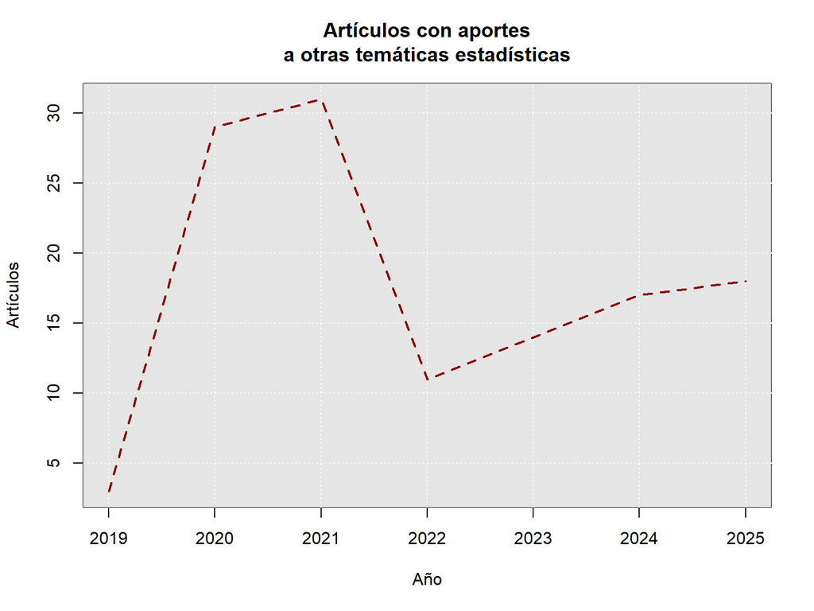

> **¿Cuál es el número total de citaciones importantes de los artículos publicados en 2025?**

> **Los 43 articulos fueron usados un total de 33 veces como eje principal de otros artículos**

### Consulta

```r
infl_cites <- dbGetQuery(con, "
  SELECT  year, SUM(influential_citations)
  FROM      articles a
  LEFT JOIN vol      v ON a.vol_id = v.id
  GROUP BY year
")
```

### Tabla

| Año | Citas influyentes |
| --- | --- |
| 2019 | 304 |
| 2020 | 283 |
| 2021 | 306 |
| 2022 | 393 |
| 2023 | 144 |
| 2024 | 51 |
| 2025 | 33 |

### Gráfico

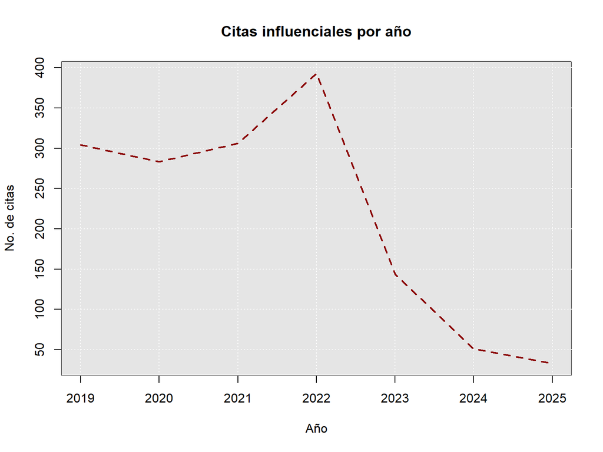

> **¿Cuál es el número promedio de referencias por artículo?**

> **Para el año 2025, se referenciaron en promedio 39 artículos.**

### Consulta

```r
avg_references <- dbGetQuery(con, "
  SELECT
      v.year,
      AVG(a.n_references) AS avg_references_per_paper
  FROM      articles a
  LEFT JOIN vol      v ON a.vol_id = v.id
  WHERE v.year != 2019
  GROUP BY v.year
  ORDER BY v.year
")
```

### Tabla

| Año | Promedio de referencias |
| --- | --- |
| 2020 | 47.38571 |
| 2021 | 51.07692 |
| 2022 | 50.10000 |
| 2023 | 49.50000 |
| 2024 | 51.00000 |
| 2025 | 39.05128 |

### Gráfico

[figure not shown]

> **¿Cuál es la referencia que más se repite en todos los artículos?**

### Consulta

```r
top_reference <- dbGetQuery(con, "
  SELECT year, reference, citations
  FROM (
    SELECT
        year,
        reference,
        citations,
        ROW_NUMBER() OVER (PARTITION BY year ORDER BY citations DESC) AS rn
    FROM (
        SELECT
            year,
            reference,
            COUNT(*) AS citations
        FROM (
            SELECT
                v.year,
                a.vol_id, a.DOI,
                r.DOI_reference AS reference
            FROM articles a
            LEFT JOIN vol v ON a.vol_id = v.id
            RIGHT JOIN ref r ON r.DOI_origin = a.DOI
            WHERE r.DOI_reference IS NOT NULL
              AND r.DOI_reference != '')
        GROUP BY year, reference
    )
  )
  WHERE rn = 1
  ORDER BY year
")
```

### Tabla

| Año | Referencia | Cantidad de citas |
| --- | --- | --- |
| 2019 | 10.18637/JSS.V040.I08 | 6 |
| 2020 | 10.18637/JSS.V040.I08 | 13 |
| 2021 | 10.18637/JSS.V040.I08 | 17 |
| 2022 | 10.18637/JSS.V077.B02 | 8 |
| 2023 | 10.18637/JSS.V040.I08 | 5 |
| 2024 | 10.18637/JSS.V035.B01 | 8 |
| 2025 | 10.18637/JSS.V035.B01 | 6 |

> **¿Cuál es el promedio de citas por artículo?**

> **Para el año 2025, se tienen en promedio 8 citas por artículo.**

### Consulta

```r
avg_citations <- dbGetQuery(con, "
  SELECT
      v.year,
      AVG(a.n_citations) AS avg_citations
  FROM      articles a
  LEFT JOIN vol      v ON a.vol_id = v.id
  GROUP BY v.year
  ORDER BY v.year
")
```

### Tabla

| Año | Citas promedio |
| --- | --- |
| 2019 | 238.08333 |
| 2020 | 51.58571 |
| 2021 | 51.15385 |
| 2022 | 54.74000 |
| 2023 | 53.73333 |
| 2024 | 19.24324 |
| 2025 | 8.00000 |

### Gráfico

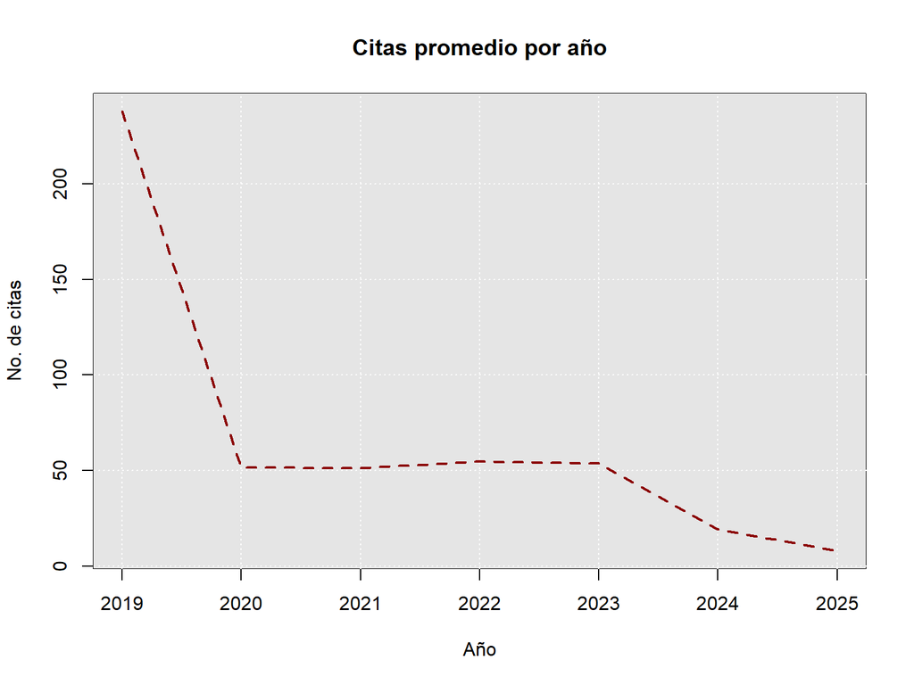

> **¿Cuál es el paper con más citas?**

> **Para el año 2025, el paper Parsimoniously Fitting Large Multivariate Random Effects in glmmTMB dentro de la categoría Estadística ha sido el paper con más citaciones (198)**

### Consulta

```r
top_cited_by_year <- dbGetQuery(con, "
  SELECT v.year, a.title, a.n_citations
  FROM articles a
  LEFT JOIN vol v ON a.vol_id = v.id
  WHERE a.n_citations = (
      SELECT MAX(a2.n_citations)
      FROM articles a2
      LEFT JOIN vol v2 ON a2.vol_id = v2.id
      WHERE v2.year = v.year
  )
  ORDER BY v.year
")
```

### Tabla

| Año | Artículo | Citas |
| --- | --- | --- |
| 2019 | stm: An R Package for Structural Topic Models | 1569 |
| 2020 | mgm: Estimating Time-Varying Mixed Graphical Models in High-Dimensional Data | 724 |
| 2021 | Bayesian Item Response Modeling in R with brms and Stan | 677 |
| 2022 | Monotone Regression: A Simple and Fast O(n) PAVA Implementation | 1381 |
| 2023 | Elastic Net Regularization Paths for All Generalized Linear Models | 517 |
| 2024 | How to Interpret Statistical Models Using marginaleffects for R and Python | 335 |
| 2025 | Parsimoniously Fitting Large Multivariate Random Effects in glmmTMB | 198 |

> **¿Cuál es el paper relacionado con Machine Learning, IA generativa o Estadística con más citas?**

> **Para el año 2025, el paper Parsimoniously Fitting Large Multivariate Random Effects in glmmTMB dentro de la categoría Estadística ha sido el paper con más citaciones (198)**

### Consulta

```r
top_cited_topic <- dbGetQuery(con, "
  SELECT v.year, a.topic, a.title,  a.n_citations
  FROM articles a
  LEFT JOIN vol v ON a.vol_id = v.id
  WHERE a.topic IN ('Machine Learning', 'Generative AI', 'Statistics')
    AND a.n_citations = (
        SELECT MAX(a2.n_citations)
        FROM articles a2
        LEFT JOIN vol v2 ON a2.vol_id = v2.id
        WHERE v2.year = v.year
          AND a2.topic = a.topic
    )
  ORDER BY v.year, a.topic, a.n_citations
")
```

### Tabla

| Año | Clasificación | Artículo | Citas |
| --- | --- | --- | --- |
| 2019 | Machine Learning | Fuzzy Forests: Extending Random Forest Feature Selection for Correlated, High-Dimensional Data | 23 |
| 2019 | Statistics | Depth and Depth-Based Classification with R Package ddalpha | 65 |
| 2020 | Machine Learning | Computing the Kolmogorov-Smirnov Distribution When the Underlying CDF is Purely Discrete, Mixed, or Continuous | 127 |
| 2020 | Statistics | Estimation of Random Utility Models in R: The mlogit Package | 204 |
| 2021 | Generative AI | qgam: Bayesian Nonparametric Quantile Regression Modeling in R | 75 |
| 2021 | Machine Learning | Nonparametric Machine Learning and Efficient Computation with Bayesian Additive Regression Trees: The BART R Package | 155 |
| 2021 | Statistics | Bayesian Item Response Modeling in R with brms and Stan | 677 |
| 2022 | Machine Learning | NeuralSens: Sensitivity Analysis of Neural Networks | 89 |
| 2022 | Statistics | evgam: An R Package for Generalized Additive Extreme Value Models | 54 |
| 2023 | Machine Learning | MLGL: An R Package Implementing Correlated Variable Selection by Hierarchical Clustering and Group-Lasso | 5 |
| 2023 | Statistics | Bayesian Structure Learning and Sampling of Bayesian Networks with the R Package BiDAG | 51 |
| 2024 | Machine Learning | fairadapt: Causal Reasoning for Fair Data Preprocessing | 18 |
| 2024 | Statistics | pyStoNED: A Python Package for Convex Regression and Frontier Estimation | 16 |
| 2025 | Machine Learning | Estimating Spatial Dynamic Panel Data Models with Unobserved Common Factors in Stata | 6 |
| 2025 | Statistics | Parsimoniously Fitting Large Multivariate Random Effects in glmmTMB | 198 |

> **¿Cuál es el paper relacionado con Machine Learning, IA generativa o Estadística con más citas influyentes?**

> **Para el año 2025, el paper Parsimoniously Fitting Large Multivariate Random Effects in glmmTMB dentro de la categoría Estadística ha sido el paper con más citaciones influyenyes (24)**

### Consulta

```r
top_downloaded_topic <- dbGetQuery(con, "
  SELECT v.year, a.topic, a.title,  a.influential_citations
  FROM articles a
  LEFT JOIN vol v ON a.vol_id = v.id
  WHERE a.topic IN ('Machine Learning', 'Generative AI', 'Statistics')
    AND a.influential_citations = (
        SELECT MAX(a2.influential_citations)
        FROM articles a2
        LEFT JOIN vol v2 ON a2.vol_id = v2.id
        WHERE v2.year = v.year
          AND a2.topic = a.topic
    )
  ORDER BY v.year, a.topic, a.influential_citations
")
```

### Tabla

| Año | Clasificación | Artículo | Citas influyentes |
| --- | --- | --- | --- |
| 2019 | Machine Learning | Fuzzy Forests: Extending Random Forest Feature Selection for Correlated, High-Dimensional Data | 1 |
| 2019 | Statistics | Depth and Depth-Based Classification with R Package ddalpha | 5 |
| 2019 | Statistics | nprobust: Nonparametric Kernel-Based Estimation and Robust Bias-Corrected Inference | 5 |
| 2020 | Machine Learning | Computing the Kolmogorov-Smirnov Distribution When the Underlying CDF is Purely Discrete, Mixed, or Continuous | 6 |
| 2020 | Statistics | Estimation of Random Utility Models in R: The mlogit Package | 19 |
| 2021 | Generative AI | qgam: Bayesian Nonparametric Quantile Regression Modeling in R | 8 |
| 2021 | Machine Learning | Nonparametric Machine Learning and Efficient Computation with Bayesian Additive Regression Trees: The BART R Package | 12 |
| 2021 | Statistics | Bayesian Item Response Modeling in R with brms and Stan | 112 |
| 2022 | Machine Learning | NeuralSens: Sensitivity Analysis of Neural Networks | 11 |
| 2022 | Statistics | evgam: An R Package for Generalized Additive Extreme Value Models | 6 |
| 2023 | Machine Learning | MLGL: An R Package Implementing Correlated Variable Selection by Hierarchical Clustering and Group-Lasso | 0 |
| 2023 | Statistics | Additive Bayesian Network Modeling with the R Package abn | 6 |
| 2024 | Machine Learning | makemyprior: Intuitive Construction of Joint Priors for Variance Parameters in R | 1 |
| 2024 | Machine Learning | fairadapt: Causal Reasoning for Fair Data Preprocessing | 1 |
| 2024 | Statistics | gcimpute: A Package for Missing Data Imputation | 1 |
| 2024 | Statistics | Modeling Big, Heterogeneous, Non-Gaussian Spatial and Spatio-Temporal Data Using FRK | 1 |
| 2024 | Statistics | pyStoNED: A Python Package for Convex Regression and Frontier Estimation | 1 |
| 2024 | Statistics | Estimating Conditional Distributions with Neural Networks Using R Package deeptrafo | 1 |
| 2025 | Machine Learning | dame-flame: A Python Package Providing Fast Interpretable Matching for Causal Inference | 0 |
| 2025 | Machine Learning | Estimating Spatial Dynamic Panel Data Models with Unobserved Common Factors in Stata | 0 |
| 2025 | Machine Learning | Exploring Data Subsets with vtree | 0 |
| 2025 | Statistics | Parsimoniously Fitting Large Multivariate Random Effects in glmmTMB | 24 |

# Clasificación temática

La clasificación temática de los artículos se realizó de forma automática mediante un modelo de lenguaje grande (LLM) ejecutado localmente con [Ollama](https://ollama.com/), evitando así el envío de información a servicios externos y eliminando la dependencia de APIs de pago.

El modelo empleado fue `llama3.2:3b`, una versión compacta y eficiente adecuada para tareas de clasificación de texto. Cada artículo fue clasificado en una de cuatro categorías mutuamente excluyentes a partir de su abstract:

- **Machine Learning:** artículos relacionados con metodología de ML, incluyendo clustering, clasificación, predicción, redes neuronales, aprendizaje supervisado/no supervisado e implementaciones de software de algoritmos de ML.
- **IA Generativa:** artículos relacionados con modelos generativos, incluyendo LLMs, generación de texto e imágenes, modelos de difusión, GANs y transformers.
- **Estadística:** artículos relacionados con metodología estadística, incluyendo inferencia, pruebas de hipótesis, regresión, diseño experimental, modelos estadísticos y sus implementaciones en software.
- **Otro:** artículos que aplican métodos existentes a un dominio específico sin contribución metodológica propia.

El proceso se implementó dentro del script `scrapping.R` y puede resumirse así:

```r
while (!ping_ollama(silent = TRUE)) {
  message(
    "\nOllama is not running.",
    "\n- If not installed, download it from: https://ollama.com/download",
    "\n- If already installed, run in the terminal: ollama serve\n"
  )
  invisible(readline("Press Enter to try again..."))
}

if (!check_model_installed("llama3.2:3b", check_only = T)){
  pull_model("llama3.2:3b", verbose = T)
}

total.art <- nrow(articles)
count <- 1
clas <- c()

for (info in articles$abstract){
  cat(sprintf('* Classifying articles: (%d/%d) ⌛\r', count, total.art))
  response <- query(
    tibble::tribble(
      ~role,    ~content,
      "system", "Classify the following abstract into exactly one of these categories:
- Machine Learning: papers related to ML methodology, including clustering, classification, prediction, neural networks, deep learning, supervised/unsupervised learning, software implementations of ML algorithms, etc.
- Generative AI: papers related to generative models, including large language models, text/image generation, diffusion models, GANs, transformers, LLMs, etc.
- Statistics: papers related to statistical methodology, including inference, hypothesis testing, probability, regression, experimental design, statistical models, clinical trial design, and software implementations of statistical methods.
- Other: papers that apply existing methods to a specific domain problem without any methodological focus.

Reply in this exact format:
  Reasoning: <Reasoning behind why the category election>
  Classification: <category>",
      "user", info),
    model = "llama3.2:3b",
    stream  = FALSE,
    verbose = FALSE,
    keep_alive = 0,
    model_params = list(temperature = 0, seed = 0513)
  )
  clas <- c(clas,
             response[[1]]$message$content |>
               str_extract('(?<=Classification: ).*'))
  count <- count + 1
}

articles$topic <- clas
cat('* Classifying articles: CHECK ✅              \n')
beepr::beep()
```

Para cada abstract, el modelo recibía un *system prompt* con instrucciones precisas que le pedían responder en un formato estructurado, extrayendo un razonamiento explícito antes de emitir la categoría final. Esto permite reproducir y auditar las decisiones de clasificación. La temperatura se fijó en `0` y la semilla en `0513` para garantizar la reproducibilidad de los resultados.

El script verifica automáticamente que Ollama esté en ejecución y que el modelo `llama3.2:3b` esté instalado antes de iniciar el proceso; en caso contrario, descarga el modelo o solicita al usuario que inicie el servicio. La categoría asignada a cada artículo quedó almacenada en la columna `topic` de la tabla `articles`, y fue utilizada posteriormente en las consultas SQL para filtrar y comparar artículos según su área temática.

# Conclusión

El ejercicio permitió construir un pipeline completo de extracción, almacenamiento y análisis de información bibliométrica sobre el JSS, integrando scrapping web, consultas a una API externa y clasificación automática mediante un LLM local. Sin embargo, el proceso evidenció algunas limitaciones que vale la pena destacar.

En cuanto a las métricas de impacto, si bien Semantic Scholar ofrece una cobertura amplia y una API de acceso libre, las cifras de citación que reporta difieren de forma notable de las de otras plataformas como Google Scholar. Esto implica que las conclusiones derivadas de dichas métricas deben interpretarse con cautela, ya que podrían no reflejar con precisión la relevancia real de los artículos dentro de la comunidad. En futuros ejercicios sería recomendable contrastar las métricas entre fuentes o justificar explícitamente la elección de una sobre otra.

Por otro lado, la ausencia de DOI en algunos artículos del sitio del JSS dificultó la construcción de la base de datos relacional, dado que el DOI actúa como clave primaria de la tabla `articles` y como punto de entrada a Semantic Scholar. Para subsanar esto, sería necesario modificar parcialmente el esquema de scrapping, ya sea incorporando un identificador alternativo o complementando la información desde otras fuentes.